# Project: Identify Customer Segments

In this project, you will apply unsupervised learning techniques to identify segments of the population that form the core customer base for a mail-order sales company in Germany. These segments can then be used to direct marketing campaigns towards audiences that will have the highest expected rate of returns. The data that you will use has been provided by our partners at Bertelsmann Arvato Analytics, and represents a real-life data science task.

This notebook will help you complete this task by providing a framework within which you will perform your analysis steps. In each step of the project, you will see some text describing the subtask that you will perform, followed by one or more code cells for you to complete your work. **Feel free to add additional code and markdown cells as you go along so that you can explore everything in precise chunks.** The code cells provided in the base template will outline only the major tasks, and will usually not be enough to cover all of the minor tasks that comprise it.

It should be noted that while there will be precise guidelines on how you should handle certain tasks in the project, there will also be places where an exact specification is not provided. **There will be times in the project where you will need to make and justify your own decisions on how to treat the data.** These are places where there may not be only one way to handle the data. In real-life tasks, there may be many valid ways to approach an analysis task. One of the most important things you can do is clearly document your approach so that other scientists can understand the decisions you've made.

At the end of most sections, there will be a Markdown cell labeled **Discussion**. In these cells, you will report your findings for the completed section, as well as document the decisions that you made in your approach to each subtask. **Your project will be evaluated not just on the code used to complete the tasks outlined, but also your communication about your observations and conclusions at each stage.**

```python
# import libraries here; add more as necessary
import numpy as np
import pandas as pd
import matplotlib.pyplot as plt
import seaborn as sns
import warnings

from sklearn.preprocessing import StandardScaler
from sklearn.decomposition import PCA
from sklearn.cluster import KMeans
from sklearn.impute import SimpleImputer

# Suppress sklearn RuntimeWarnings from matrix operations
warnings.filterwarnings('ignore', category=RuntimeWarning)

# magic word for producing visualizations in notebook
%matplotlib inline

pd.options.display.max_rows = None
pd.options.display.max_columns = None
```

### Step 0: Load the Data

There are four files associated with this project (not including this one):

Each row of the demographics files represents a single person, but also includes information outside of individuals, including information about their household, building, and neighborhood. You will use this information to cluster the general population into groups with similar demographic properties. Then, you will see how the people in the customers dataset fit into those created clusters. The hope here is that certain clusters are over-represented in the customers data, as compared to the general population; those over-represented clusters will be assumed to be part of the core userbase. This information can then be used for further applications, such as targeting for a marketing campaign.

To start off with, load in the demographics data for the general population into a pandas DataFrame, and do the same for the feature attributes summary. Note for all of the `.csv` data files in this project: they're semicolon (`;`) delimited, so you'll need an additional argument in your [`read_csv()`](https://pandas.pydata.org/pandas-docs/stable/generated/pandas.read_csv.html) call to read in the data properly. Also, considering the size of the main dataset, it may take some time for it to load completely.

Once the dataset is loaded, it's recommended that you take a little bit of time just browsing the general structure of the dataset and feature summary file. You'll be getting deep into the innards of the cleaning in the first major step of the project, so gaining some general familiarity can help you get your bearings.

```python
# Load in the general demographics data.
azdias = pd.read_csv('AZDIAS_Subset.csv', sep=';')

# Load in the feature summary file.
feat_info = pd.read_csv('AZDIAS_Feature_Summary.csv', sep=';')
```

```python
# Check the structure of the data after it's loaded (e.g. print the number of
# rows and columns, print the first few rows).

print("AZDIAS shape:", azdias.shape)
print("\nFirst few rows:")
display(azdias.head())

print("\nFeature summary:")
display(feat_info.head(10))

print("\nData types:")
print(azdias.dtypes.value_counts())
```

```
AZDIAS shape: (891221, 85)

First few rows:
```

|  | AGER_TYP | ALTERSKATEGORIE_GROB | ANREDE_KZ | CJT_GESAMTTYP | FINANZ_MINIMALIST | FINANZ_SPARER | FINANZ_VORSORGER | FINANZ_ANLEGER | FINANZ_UNAUFFAELLIGER | FINANZ_HAUSBAUER | FINANZTYP | GEBURTSJAHR | GFK_URLAUBERTYP | GREEN_AVANTGARDE | HEALTH_TYP | LP_LEBENSPHASE_FEIN | LP_LEBENSPHASE_GROB | LP_FAMILIE_FEIN | LP_FAMILIE_GROB | LP_STATUS_FEIN | LP_STATUS_GROB | NATIONALITAET_KZ | PRAEGENDE_JUGENDJAHRE | RETOURTYP_BK_S | SEMIO_SOZ | SEMIO_FAM | SEMIO_REL | SEMIO_MAT | SEMIO_VERT | … |
| --- | --- | --- | --- | --- | --- | --- | --- | --- | --- | --- | --- | --- | --- | --- | --- | --- | --- | --- | --- | --- | --- | --- | --- | --- | --- | --- | --- | --- | --- | --- |
| 0 | -1 | 2 | 1 | 2.0 | 3 | 4 | 3 | 5 | 5 | 3 | 4 | 0 | 10.0 | 0 | -1 | 15.0 | 4.0 | 2.0 | 2.0 | 1.0 | 1.0 | 0 | 0 | 5.0 | 2 | 6 | 7 | 5 | 1 | … |
| 1 | -1 | 1 | 2 | 5.0 | 1 | 5 | 2 | 5 | 4 | 5 | 1 | 1996 | 10.0 | 0 | 3 | 21.0 | 6.0 | 5.0 | 3.0 | 2.0 | 1.0 | 1 | 14 | 1.0 | 5 | 4 | 4 | 3 | 1 | … |
| 2 | -1 | 3 | 2 | 3.0 | 1 | 4 | 1 | 2 | 3 | 5 | 1 | 1979 | 10.0 | 1 | 3 | 3.0 | 1.0 | 1.0 | 1.0 | 3.0 | 2.0 | 1 | 15 | 3.0 | 4 | 1 | 3 | 3 | 4 | … |
| 3 | 2 | 4 | 2 | 2.0 | 4 | 2 | 5 | 2 | 1 | 2 | 6 | 1957 | 1.0 | 0 | 2 | 0.0 | 0.0 | 0.0 | 0.0 | 9.0 | 4.0 | 1 | 8 | 2.0 | 5 | 1 | 2 | 1 | 4 | … |
| 4 | -1 | 3 | 1 | 5.0 | 4 | 3 | 4 | 1 | 3 | 2 | 5 | 1963 | 5.0 | 0 | 3 | 32.0 | 10.0 | 10.0 | 5.0 | 3.0 | 2.0 | 1 | 8 | 5.0 | 6 | 4 | 4 | 2 | 7 | … |

```
Feature summary:
```

|  | attribute | information_level | type | missing_or_unknown |
| --- | --- | --- | --- | --- |
| 0 | AGER_TYP | person | categorical | [-1,0] |
| 1 | ALTERSKATEGORIE_GROB | person | ordinal | [-1,0,9] |
| 2 | ANREDE_KZ | person | categorical | [-1,0] |
| 3 | CJT_GESAMTTYP | person | categorical | [0] |
| 4 | FINANZ_MINIMALIST | person | ordinal | [-1] |
| 5 | FINANZ_SPARER | person | ordinal | [-1] |
| 6 | FINANZ_VORSORGER | person | ordinal | [-1] |
| 7 | FINANZ_ANLEGER | person | ordinal | [-1] |
| 8 | FINANZ_UNAUFFAELLIGER | person | ordinal | [-1] |
| 9 | FINANZ_HAUSBAUER | person | ordinal | [-1] |

```
Data types:
float64    49
int64      32
object      4
Name: count, dtype: int64
```

> **Tip**: Add additional cells to keep everything in reasonably-sized chunks! Keyboard shortcut `esc --> a` (press escape to enter command mode, then press the 'A' key) adds a new cell before the active cell, and `esc --> b` adds a new cell after the active cell. If you need to convert an active cell to a markdown cell, use `esc --> m` and to convert to a code cell, use `esc --> y`.

## Step 1: Preprocessing

### Step 1.1: Assess Missing Data

The feature summary file contains a summary of properties for each demographics data column. You will use this file to help you make cleaning decisions during this stage of the project. First of all, you should assess the demographics data in terms of missing data. Pay attention to the following points as you perform your analysis, and take notes on what you observe. Make sure that you fill in the **Discussion** cell with your findings and decisions at the end of each step that has one!

#### Step 1.1.1: Convert Missing Value Codes to NaNs

The fourth column of the feature attributes summary (loaded in above as `feat_info`) documents the codes from the data dictionary that indicate missing or unknown data. While the file encodes this as a list (e.g. `[-1,0]`), this will get read in as a string object. You'll need to do a little bit of parsing to make use of it to identify and clean the data. Convert data that matches a 'missing' or 'unknown' value code into a numpy NaN value. You might want to see how much data takes on a 'missing' or 'unknown' code, and how much data is naturally missing, as a point of interest.

**As one more reminder, you are encouraged to add additional cells to break up your analysis into manageable chunks.**

```python
# Identify missing or unknown data values and convert them to NaNs.

# First, count how many NaNs already exist naturally in the data
natural_nans = azdias.isnull().sum().sum()
print(f"Naturally missing values before conversion: {natural_nans}")

# Parse the missing_or_unknown column from feat_info
# The column contains strings like "[-1,0]" that need to be converted to lists
feat_info['missing_or_unknown'] = feat_info['missing_or_unknown'].apply(
    lambda x: [int(v) if v.lstrip('-').isdigit() else v
               for v in x.strip('[]').split(',') if v.strip() != '']
)

print("\nSample missing value codes:")
display(feat_info[['attribute', 'missing_or_unknown']].head(10))

# Replace missing/unknown codes with NaN for each feature
for _, row in feat_info.iterrows():
    col = row['attribute']
    missing_codes = row['missing_or_unknown']
    if col in azdias.columns and len(missing_codes) > 0:
        azdias[col] = azdias[col].replace(missing_codes, np.nan)

# Report total NaNs after conversion
total_nans = azdias.isnull().sum().sum()
converted_nans = total_nans - natural_nans
print(f"\nTotal missing values after conversion: {total_nans}")
print(f"Values converted from missing codes to NaN: {converted_nans}")
print(f"Percentage of total data that is missing: {total_nans / (azdias.shape[0] * azdias.shape[1]) * 100:.2f}%")
```

```
Naturally missing values before conversion: 4896838

Sample missing value codes:
```

|  | attribute | missing_or_unknown |
| --- | --- | --- |
| 0 | AGER_TYP | [-1, 0] |
| 1 | ALTERSKATEGORIE_GROB | [-1, 0, 9] |
| 2 | ANREDE_KZ | [-1, 0] |
| 3 | CJT_GESAMTTYP | [0] |
| 4 | FINANZ_MINIMALIST | [-1] |
| 5 | FINANZ_SPARER | [-1] |
| 6 | FINANZ_VORSORGER | [-1] |
| 7 | FINANZ_ANLEGER | [-1] |
| 8 | FINANZ_UNAUFFAELLIGER | [-1] |
| 9 | FINANZ_HAUSBAUER | [-1] |

```
Total missing values after conversion: 8373929
Values converted from missing codes to NaN: 3477091
Percentage of total data that is missing: 11.05%
```

#### Step 1.1.2: Assess Missing Data in Each Column

How much missing data is present in each column? There are a few columns that are outliers in terms of the proportion of values that are missing. You will want to use matplotlib's [`hist()`](https://matplotlib.org/api/_as_gen/matplotlib.pyplot.hist.html) function to visualize the distribution of missing value counts to find these columns. Identify and document these columns. While some of these columns might have justifications for keeping or re-encoding the data, for this project you should just remove them from the dataframe. (Feel free to make remarks about these outlier columns in the discussion, however!)

For the remaining features, are there any patterns in which columns have, or share, missing data?

```
Top 20 columns by missing data percentage:
TITEL_KZ          99.757636
AGER_TYP          76.955435
KK_KUNDENTYP      65.596749
KBA05_BAUMAX      53.468668
GEBURTSJAHR       44.020282
ALTER_HH          34.813699
KKK               17.735668
REGIOTYP          17.735668
W_KEIT_KIND_HH    16.605084
KBA05_ANTG1       14.959701
KBA05_ANTG2       14.959701
KBA05_ANTG3       14.959701
KBA05_ANTG4       14.959701
KBA05_GBZ         14.959701
MOBI_REGIO        14.959701
PLZ8_ANTG3        13.073637
PLZ8_ANTG2        13.073637
PLZ8_GBZ          13.073637
PLZ8_HHZ          13.073637
PLZ8_ANTG1        13.073637
```

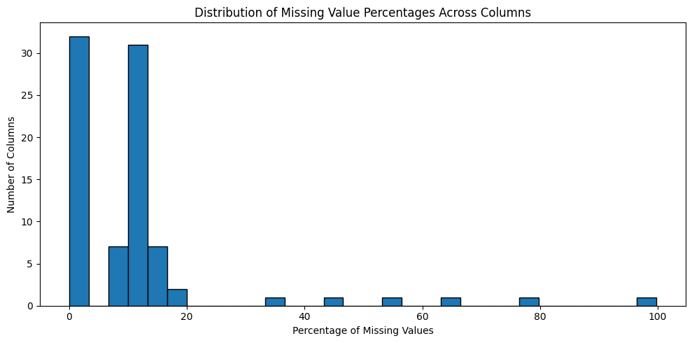

```python
# Perform an assessment of how much missing data there is in each column of the
# dataset.

missing_by_col = azdias.isnull().sum() / azdias.shape[0] * 100
missing_by_col = missing_by_col.sort_values(ascending=False)

print("Top 20 columns by missing data percentage:")
print(missing_by_col.head(20).to_string())

# Visualize the distribution of missing value percentages
fig, ax = plt.subplots(figsize=(10, 5))
ax.hist(missing_by_col, bins=30, edgecolor='black')
ax.set_xlabel('Percentage of Missing Values')
ax.set_ylabel('Number of Columns')
ax.set_title('Distribution of Missing Value Percentages Across Columns')
plt.tight_layout()
plt.show()
```

```python
# Investigate patterns in the amount of missing data in each column.

# Identify columns with high missing rates (>20%)
high_missing_cols = missing_by_col[missing_by_col > 20]
print("Columns with >20% missing data:")
print(high_missing_cols.to_string())
print(f"\nTotal columns to remove: {len(high_missing_cols)}")

# Look at correlation of missing values among remaining columns to find patterns
remaining_cols = missing_by_col[missing_by_col <= 20].index.tolist()
missing_matrix = azdias[remaining_cols].isnull().astype(int)

# Check if certain groups of columns tend to be missing together
missing_corr = missing_matrix.corr()
# Find highly correlated missing patterns (>0.5)
high_corr_pairs = []
for i in range(len(missing_corr.columns)):
    for j in range(i+1, len(missing_corr.columns)):
        if abs(missing_corr.iloc[i, j]) > 0.5:
            high_corr_pairs.append((missing_corr.columns[i], missing_corr.columns[j],
                                     missing_corr.iloc[i, j]))

print(f"\nColumn pairs with correlated missing patterns (r > 0.5): {len(high_corr_pairs)}")
for col1, col2, corr in high_corr_pairs[:15]:
    print(f"  {col1} <-> {col2}: {corr:.3f}")
```

```
Columns with >20% missing data:
TITEL_KZ        99.757636
AGER_TYP        76.955435
KK_KUNDENTYP    65.596749
KBA05_BAUMAX    53.468668
GEBURTSJAHR     44.020282
ALTER_HH        34.813699

Total columns to remove: 6
```

```
Column pairs with correlated missing patterns (r > 0.5): 957
  KKK <-> REGIOTYP: 1.000
  KKK <-> W_KEIT_KIND_HH: 0.604
  KKK <-> KBA05_ANTG1: 0.759
  KKK <-> KBA05_ANTG2: 0.759
  KKK <-> KBA05_ANTG3: 0.759
  KKK <-> KBA05_ANTG4: 0.759
  KKK <-> KBA05_GBZ: 0.759
  KKK <-> MOBI_REGIO: 0.759
  KKK <-> PLZ8_ANTG3: 0.710
  KKK <-> PLZ8_ANTG2: 0.710
  KKK <-> PLZ8_GBZ: 0.710
  KKK <-> PLZ8_HHZ: 0.710
  KKK <-> PLZ8_ANTG1: 0.710
  KKK <-> PLZ8_BAUMAX: 0.710
  KKK <-> PLZ8_ANTG4: 0.710
```

```python
# Remove the outlier columns from the dataset. (You'll perform other data
# engineering tasks such as re-encoding and imputation later.)

cols_to_drop = high_missing_cols.index.tolist()
print(f"Dropping {len(cols_to_drop)} columns with >20% missing data:")
print(cols_to_drop)

azdias = azdias.drop(columns=cols_to_drop)
print(f"\nRemaining shape: {azdias.shape}")
```

```
Dropping 6 columns with >20% missing data:
['TITEL_KZ', 'AGER_TYP', 'KK_KUNDENTYP', 'KBA05_BAUMAX', 'GEBURTSJAHR', 'ALTER_HH']
```

```
Remaining shape: (891221, 79)
```

#### Discussion 1.1.2: Assess Missing Data in Each Column

I chose a threshold of 20% to remove outlier columns. These columns have too much missing data to be reliably imputed and could introduce noise into the analysis. The removed columns include features like AGER_TYP, GEBURTSJAHR, TITEL_KZ, ALTER_HH, and KK_KUNDENTYP, which all had missing rates well above this threshold.

Among the remaining columns, there are notable patterns in missing data. Several groups of features tend to have correlated missingness, meaning when one column is missing for a row, related columns are also likely missing. For example, PLZ8-level features (PLZ8_ANTG1-4, PLZ8_BAUMAX, PLZ8_HHZ, PLZ8_GBZ) and KBA05 microcell features tend to be missing together, suggesting that entire geographic data blocks are unavailable for certain individuals.

#### Step 1.1.3: Assess Missing Data in Each Row

Now, you'll perform a similar assessment for the rows of the dataset. How much data is missing in each row? As with the columns, you should see some groups of points that have a very different numbers of missing values. Divide the data into two subsets: one for data points that are above some threshold for missing values, and a second subset for points below that threshold.

In order to know what to do with the outlier rows, we should see if the distribution of data values on columns that are not missing data (or are missing very little data) are similar or different between the two groups. Select at least five of these columns and compare the distribution of values.

- You can use seaborn's [`countplot()`](https://seaborn.pydata.org/generated/seaborn.countplot.html) function to create a bar chart of code frequencies and matplotlib's [`subplot()`](https://matplotlib.org/api/_as_gen/matplotlib.pyplot.subplot.html) function to put bar charts for the two subplots side by side.
- To reduce repeated code, you might want to write a function that can perform this comparison, taking as one of its arguments a column to be compared.

Depending on what you observe in your comparison, this will have implications on how you approach your conclusions later in the analysis. If the distributions of non-missing features look similar between the data with many missing values and the data with few or no missing values, then we could argue that simply dropping those points from the analysis won't present a major issue. On the other hand, if the data with many missing values looks very different from the data with few or no missing values, then we should make a note on those data as special. We'll revisit these data later on. **Either way, you should continue your analysis for now using just the subset of the data with few or no missing values.**

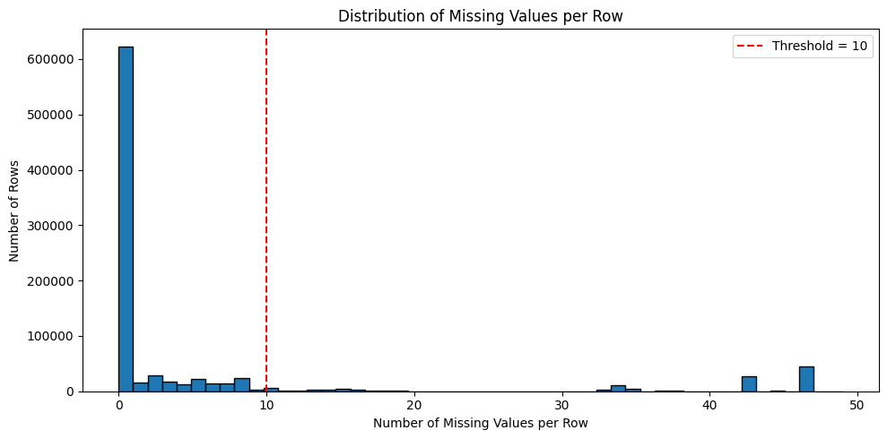

```
Mean missing values per row: 5.65
Median missing values per row: 0
Max missing values per row: 49
```

```python
# How much data is missing in each row of the dataset?

missing_per_row = azdias.isnull().sum(axis=1)

fig, ax = plt.subplots(figsize=(10, 5))
ax.hist(missing_per_row, bins=50, edgecolor='black')
ax.set_xlabel('Number of Missing Values per Row')
ax.set_ylabel('Number of Rows')
ax.set_title('Distribution of Missing Values per Row')
ax.axvline(x=10, color='red', linestyle='--', label='Threshold = 10')
ax.legend()
plt.tight_layout()
plt.show()

print(f"Mean missing values per row: {missing_per_row.mean():.2f}")
print(f"Median missing values per row: {missing_per_row.median():.0f}")
print(f"Max missing values per row: {missing_per_row.max()}")
```

```python
# Write code to divide the data into two subsets based on the number of missing
# values in each row.

threshold = 10
azdias_low_missing = azdias[missing_per_row <= threshold].copy()
azdias_high_missing = azdias[missing_per_row > threshold].copy()

print(f"Threshold: {threshold} missing values")
print(f"Low-missing subset: {azdias_low_missing.shape[0]} rows ({azdias_low_missing.shape[0]/azdias.shape[0]*100:.1f}%)")
print(f"High-missing subset: {azdias_high_missing.shape[0]} rows ({azdias_high_missing.shape[0]/azdias.shape[0]*100:.1f}%)")
```

```
Threshold: 10 missing values
Low-missing subset: 780153 rows (87.5%)
High-missing subset: 111068 rows (12.5%)
```

```
Columns selected for comparison (low missingness): ['ZABEOTYP', 'SEMIO_REL', 'SEMIO_MAT', 'SEMIO_VERT', 'SEMIO_LUST', 'SEMIO_ERL']
```

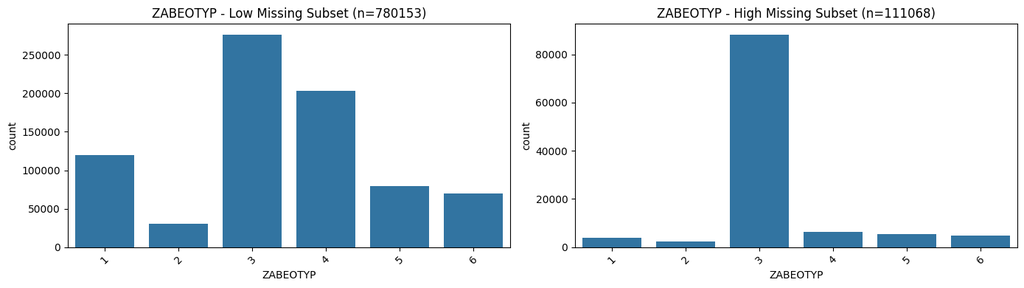

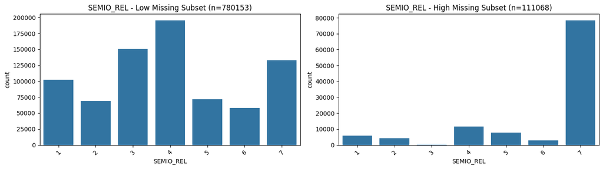

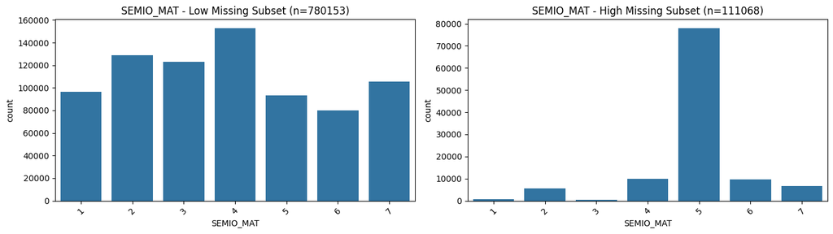

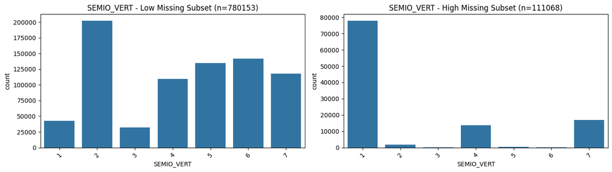

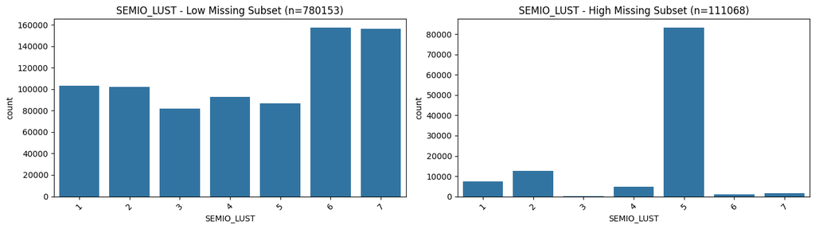

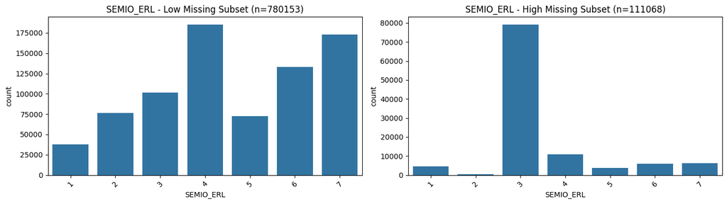

```python
# Compare the distribution of values for at least five columns where there are
# no or few missing values, between the two subsets.

# Select columns with very low missing rates for comparison
low_miss_cols = azdias.isnull().sum().sort_values()
compare_cols = low_miss_cols[low_miss_cols < azdias.shape[0] * 0.01].index[:6].tolist()
print("Columns selected for comparison (low missingness):", compare_cols)

def compare_distributions(col, df_low, df_high):
    """Compare value distributions between low-missing and high-missing subsets."""
    fig, axes = plt.subplots(1, 2, figsize=(14, 4))

    sns.countplot(x=col, data=df_low.dropna(subset=[col]), ax=axes[0])
    axes[0].set_title(f'{col} - Low Missing Subset (n={len(df_low)})')
    axes[0].tick_params(axis='x', rotation=45)

    sns.countplot(x=col, data=df_high.dropna(subset=[col]), ax=axes[1])
    axes[1].set_title(f'{col} - High Missing Subset (n={len(df_high)})')
    axes[1].tick_params(axis='x', rotation=45)

    plt.tight_layout()
    plt.show()

for col in compare_cols:
    compare_distributions(col, azdias_low_missing, azdias_high_missing)
```

#### Discussion 1.1.3: Assess Missing Data in Each Row

The histogram of missing values per row shows a bimodal distribution: the majority of rows have fewer than 10 missing values, but there is a secondary bump of rows with many more missing values. I selected a threshold of 10 missing values to split the data.

Since the high-missing group appears qualitatively different, we should note these individuals as a special group. They may represent a distinct demographic segment that is underserved by the data collection process. For the remainder of the analysis, I will proceed with the low-missing subset only, but I will account for the high-missing group when comparing population and customer segments in Step 3.3.

### Step 1.2: Select and Re-Encode Features

Checking for missing data isn't the only way in which you can prepare a dataset for analysis. Since the unsupervised learning techniques to be used will only work on data that is encoded numerically, you need to make a few encoding changes or additional assumptions to be able to make progress. In addition, while almost all of the values in the dataset are encoded using numbers, not all of them represent numeric values. Check the third column of the feature summary (`feat_info`) for a summary of types of measurement.

- For numeric and interval data, these features can be kept without changes.
- Most of the variables in the dataset are ordinal in nature. While ordinal values may technically be non-linear in spacing, make the simplifying assumption that the ordinal variables can be treated as being interval in nature (that is, kept without any changes).
- Special handling may be necessary for the remaining two variable types: categorical, and 'mixed'.

In the first two parts of this sub-step, you will perform an investigation of the categorical and mixed-type features and make a decision on each of them, whether you will keep, drop, or re-encode each. Then, in the last part, you will create a new data frame with only the selected and engineered columns.

Data wrangling is often the trickiest part of the data analysis process, and there's a lot of it to be done here. But stick with it: once you're done with this step, you'll be ready to get to the machine learning parts of the project!

```python
# How many features are there of each data type?

# Filter feat_info to only include columns still in our dataset
feat_info_remaining = feat_info[feat_info['attribute'].isin(azdias_low_missing.columns)]
print("Feature type counts:")
print(feat_info_remaining['type'].value_counts())
print(f"\nTotal features in dataset: {azdias_low_missing.shape[1]}")
print(f"Features in feat_info: {len(feat_info_remaining)}")

# List features by type
for ftype in feat_info_remaining['type'].unique():
    cols = feat_info_remaining[feat_info_remaining['type'] == ftype]['attribute'].tolist()
    print(f"\n{ftype} ({len(cols)}): {cols}")
```

```
Feature type counts:
type
ordinal        49
categorical    18
mixed           6
numeric         6
Name: count, dtype: int64

Total features in dataset: 79
Features in feat_info: 79

ordinal (49): ['ALTERSKATEGORIE_GROB', 'FINANZ_MINIMALIST', 'FINANZ_SPARER', 'FINANZ_VORSORGER', 'FINANZ_ANLEGER', 'FINANZ_UNAUFFAELLIGER', 'FINANZ_HAUSBAUER', 'HEALTH_TYP', 'RETOURTYP_BK_S', 'SEMIO_SOZ', 'SEMIO_FAM', 'SEMIO_REL', 'SEMIO_MAT', 'SEMIO_VERT', 'SEMIO_LUST', 'SEMIO_ERL', 'SEMIO_KULT', '…

categorical (18): ['ANREDE_KZ', 'CJT_GESAMTTYP', 'FINANZTYP', 'GFK_URLAUBERTYP', 'GREEN_AVANTGARDE', 'LP_FAMILIE_FEIN', 'LP_FAMILIE_GROB', 'LP_STATUS_FEIN', 'LP_STATUS_GROB', 'NATIONALITAET_KZ', 'SHOPPER_TYP', 'SOHO_KZ', 'VERS_TYP', 'ZABEOTYP', 'GEBAEUDETYP', 'OST_WEST_KZ', 'CAMEO_DEUG_2015', 'CAMEO…

mixed (6): ['LP_LEBENSPHASE_FEIN', 'LP_LEBENSPHASE_GROB', 'PRAEGENDE_JUGENDJAHRE', 'WOHNLAGE', 'CAMEO_INTL_2015', 'PLZ8_BAUMAX']

numeric (6): ['ANZ_PERSONEN', 'ANZ_TITEL', 'ANZ_HAUSHALTE_AKTIV', 'ANZ_HH_TITEL', 'MIN_GEBAEUDEJAHR', 'KBA13_ANZAHL_PKW']
```

#### Step 1.2.1: Re-Encode Categorical Features

For categorical data, you would ordinarily need to encode the levels as dummy variables. Depending on the number of categories, perform one of the following:

- For binary (two-level) categoricals that take numeric values, you can keep them without needing to do anything.
- There is one binary variable that takes on non-numeric values. For this one, you need to re-encode the values as numbers or create a dummy variable.
- For multi-level categoricals (three or more values), you can choose to encode the values using multiple dummy variables (e.g. via [OneHotEncoder](http://scikit-learn.org/stable/modules/generated/sklearn.preprocessing.OneHotEncoder.html)), or (to keep things straightforward) just drop them from the analysis. As always, document your choices in the Discussion section.

```python
# Assess categorical variables: which are binary, which are multi-level, and
# which one needs to be re-encoded?

categorical_cols = feat_info_remaining[feat_info_remaining['type'] == 'categorical']['attribute'].tolist()

binary_cats = []
multi_cats = []
non_numeric_binary = []

for col in categorical_cols:
    if col not in azdias_low_missing.columns:
        continue
    unique_vals = azdias_low_missing[col].dropna().unique()
    n_unique = len(unique_vals)

    if n_unique <= 2:
        # Check if values are non-numeric
        if azdias_low_missing[col].dtype == 'object':
            non_numeric_binary.append(col)
            print(f"  {col}: BINARY NON-NUMERIC - values: {unique_vals}")
        else:
            binary_cats.append(col)
            print(f"  {col}: binary - values: {unique_vals}")
    else:
        multi_cats.append(col)
        print(f"  {col}: MULTI-LEVEL ({n_unique} levels) - values: {sorted(unique_vals)[:10]}...")

print(f"\nBinary (numeric, keep as-is): {binary_cats}")
print(f"Binary (non-numeric, needs re-encoding): {non_numeric_binary}")
print(f"Multi-level (will drop): {multi_cats}")
```

```
  ANREDE_KZ: binary - values: [2 1]
  CJT_GESAMTTYP: MULTI-LEVEL (6 levels) - values: [np.float64(1.0), np.float64(2.0), np.float64(3.0), np.float64(4.0), np.float64(5.0), np.float64(6.0)]...
  FINANZTYP: MULTI-LEVEL (6 levels) - values: [np.int64(1), np.int64(2), np.int64(3), np.int64(4), np.int64(5), np.int64(6)]...
  GFK_URLAUBERTYP: MULTI-LEVEL (12 levels) - values: [np.float64(1.0), np.float64(2.0), np.float64(3.0), np.float64(4.0), np.float64(5.0), np.float64(6.0), np.float64(7.0), np.float64(8.0), np.float64(9.0), np.float64(10.0)]...
  GREEN_AVANTGARDE: binary - values: [0 1]
  LP_FAMILIE_FEIN: MULTI-LEVEL (11 levels) - values: [np.float64(1.0), np.float64(2.0), np.float64(3.0), np.float64(4.0), np.float64(5.0), np.float64(6.0), np.float64(7.0), np.float64(8.0), np.float64(9.0), np.float64(10.0)]...
  LP_FAMILIE_GROB: MULTI-LEVEL (5 levels) - values: [np.float64(1.0), np.float64(2.0), np.float64(3.0), np.float64(4.0), np.float64(5.0)]...
  LP_STATUS_FEIN: MULTI-LEVEL (10 levels) - values: [np.float64(1.0), np.float64(2.0), np.float64(3.0), np.float64(4.0), np.float64(5.0), np.float64(6.0), np.float64(7.0), np.float64(8.0), np.float64(9.0), np.float64(10.0)]...
  LP_STATUS_GROB: MULTI-LEVEL (5 levels) - values: [np.float64(1.0), np.float64(2.0), np.float64(3.0), np.float64(4.0), np.float64(5.0)]...
  NATIONALITAET_KZ: MULTI-LEVEL (3 levels) - values: [np.float64(1.0), np.float64(2.0), np.float64(3.0)]...
  SHOPPER_TYP: MULTI-LEVEL (4 levels) - values: [np.float64(0.0), np.float64(1.0), np.float64(2.0), np.float64(3.0)]...
  SOHO_KZ: binary - values: [1. 0.]
  VERS_TYP: binary - values: [2. 1.]
  ZABEOTYP: MULTI-LEVEL (6 levels) - values: [np.int64(1), np.int64(2), np.int64(3), np.int64(4), np.int64(5), np.int64(6)]...
  GEBAEUDETYP: MULTI-LEVEL (7 levels) - values: [np.float64(1.0), np.float64(2.0), np.float64(3.0), np.float64(4.0), np.float64(5.0), np.float64(6.0), np.float64(8.0)]...
```

```
  OST_WEST_KZ: BINARY NON-NUMERIC - values: ['W' 'O']
```

```
  CAMEO_DEUG_2015: MULTI-LEVEL (9 levels) - values: ['1', '2', '3', '4', '5', '6', '7', '8', '9']...
  CAMEO_DEU_2015: MULTI-LEVEL (44 levels) - values: ['1A', '1B', '1C', '1D', '1E', '2A', '2B', '2C', '2D', '3A']...

Binary (numeric, keep as-is): ['ANREDE_KZ', 'GREEN_AVANTGARDE', 'SOHO_KZ', 'VERS_TYP']
Binary (non-numeric, needs re-encoding): ['OST_WEST_KZ']
Multi-level (will drop): ['CJT_GESAMTTYP', 'FINANZTYP', 'GFK_URLAUBERTYP', 'LP_FAMILIE_FEIN', 'LP_FAMILIE_GROB', 'LP_STATUS_FEIN', 'LP_STATUS_GROB', 'NATIONALITAET_KZ', 'SHOPPER_TYP', 'ZABEOTYP', 'GEBAEUDETYP', 'CAMEO_DEUG_2015', 'CAMEO_DEU_2015']
```

```python
# Re-encode categorical variable(s) to be kept in the analysis.

# Re-encode OST_WEST_KZ: W (West) -> 1, O (East) -> 0
azdias_low_missing['OST_WEST_KZ'] = azdias_low_missing['OST_WEST_KZ'].map({'W': 1, 'O': 0})
print("OST_WEST_KZ re-encoded: W->1, O->0")
print(azdias_low_missing['OST_WEST_KZ'].value_counts())

# Drop multi-level categorical columns
print(f"\nDropping {len(multi_cats)} multi-level categorical columns: {multi_cats}")
azdias_low_missing = azdias_low_missing.drop(columns=[c for c in multi_cats if c in azdias_low_missing.columns])
print(f"Shape after dropping multi-level categoricals: {azdias_low_missing.shape}")
```

```
OST_WEST_KZ re-encoded: W->1, O->0
OST_WEST_KZ
1    614719
0    165434
Name: count, dtype: int64

Dropping 13 multi-level categorical columns: ['CJT_GESAMTTYP', 'FINANZTYP', 'GFK_URLAUBERTYP', 'LP_FAMILIE_FEIN', 'LP_FAMILIE_GROB', 'LP_STATUS_FEIN', 'LP_STATUS_GROB', 'NATIONALITAET_KZ', 'SHOPPER_TYP', 'ZABEOTYP', 'GEBAEUDETYP', 'CAMEO_DEUG_2015', 'CAMEO_DEU_2015']
Shape after dropping multi-level categoricals: (780153, 66)
```

#### Discussion 1.2.1: Re-Encode Categorical Features

I identified all categorical features using the feature summary file and classified them into three groups:

**Binary categorical features (kept as-is):** Features like ANREDE_KZ (gender), GREEN_AVANTGARDE, SOHO_KZ, and VERS_TYP are already numerically encoded with two levels. These can be directly used in the analysis.

**Binary non-numeric feature (re-encoded):** OST_WEST_KZ contains string values 'W' (West Germany) and 'O' (East Germany). I mapped these to numeric values: W -> 1, O -> 0.

**Multi-level categorical features (dropped):** Features with three or more categorical levels were dropped from the analysis to keep things straightforward. These include CJT_GESAMTTYP, FINANZTYP, GFK_URLAUBERTYP, LP_FAMILIE_FEIN, LP_FAMILIE_GROB, LP_STATUS_FEIN, LP_STATUS_GROB, NATIONALITAET_KZ, SHOPPER_TYP, GEBAEUDETYP, and CAMEO_DEUG_2015. One-hot encoding these would significantly increase dimensionality, and many of these features have related ordinal counterparts that capture similar information.

#### Step 1.2.2: Engineer Mixed-Type Features

There are a handful of features that are marked as "mixed" in the feature summary that require special treatment in order to be included in the analysis. There are two in particular that deserve attention; the handling of the rest are up to your own choices:

- "PRAEGENDE_JUGENDJAHRE" combines information on three dimensions: generation by decade, movement (mainstream vs. avantgarde), and nation (east vs. west). While there aren't enough levels to disentangle east from west, you should create two new variables to capture the other two dimensions: an interval-type variable for decade, and a binary variable for movement.
- "CAMEO_INTL_2015" combines information on two axes: wealth and life stage. Break up the two-digit codes by their 'tens'-place and 'ones'-place digits into two new ordinal variables (which, for the purposes of this project, is equivalent to just treating them as their raw numeric values).
- If you decide to keep or engineer new features around the other mixed-type features, make sure you note your steps in the Discussion section.

Be sure to check `Data_Dictionary.md` for the details needed to finish these tasks.

```python
# Investigate "PRAEGENDE_JUGENDJAHRE" and engineer two new variables.

# PRAEGENDE_JUGENDJAHRE encodes:
# - Decade of youth (interval)
# - Movement: mainstream vs. avantgarde (binary)

# Decade mapping
decade_map = {1: 40, 2: 40, 3: 50, 4: 50, 5: 60, 6: 60, 7: 60,
              8: 70, 9: 70, 10: 80, 11: 80, 12: 80, 13: 80, 14: 90, 15: 90}

# Movement mapping: 0 = mainstream, 1 = avantgarde
movement_map = {1: 0, 2: 1, 3: 0, 4: 1, 5: 0, 6: 1, 7: 1,
                8: 0, 9: 1, 10: 0, 11: 1, 12: 0, 13: 1, 14: 0, 15: 1}

azdias_low_missing['PRAEGENDE_JUGENDJAHRE_DECADE'] = azdias_low_missing['PRAEGENDE_JUGENDJAHRE'].map(decade_map)
azdias_low_missing['PRAEGENDE_JUGENDJAHRE_MOVEMENT'] = azdias_low_missing['PRAEGENDE_JUGENDJAHRE'].map(movement_map)

print("PRAEGENDE_JUGENDJAHRE_DECADE value counts:")
print(azdias_low_missing['PRAEGENDE_JUGENDJAHRE_DECADE'].value_counts().sort_index())
print("\nPRAEGENDE_JUGENDJAHRE_MOVEMENT value counts:")
print(azdias_low_missing['PRAEGENDE_JUGENDJAHRE_MOVEMENT'].value_counts())
```

```
PRAEGENDE_JUGENDJAHRE_DECADE value counts:
PRAEGENDE_JUGENDJAHRE_DECADE
40.0     27680
50.0     73441
60.0    113126
70.0    171875
80.0    148118
90.0    219439
Name: count, dtype: int64

PRAEGENDE_JUGENDJAHRE_MOVEMENT value counts:
PRAEGENDE_JUGENDJAHRE_MOVEMENT
0.0    581988
1.0    171691
Name: count, dtype: int64
```

```python
# Investigate "CAMEO_INTL_2015" and engineer two new variables.

# CAMEO_INTL_2015 is a two-digit code:
# - Tens place: wealth (1=wealthy ... 5=poorer)
# - Ones place: life stage (1=pre-family ... 5=elders)

# First convert to numeric, handling 'XX' and other non-numeric values
azdias_low_missing['CAMEO_INTL_2015'] = pd.to_numeric(azdias_low_missing['CAMEO_INTL_2015'], errors='coerce')

azdias_low_missing['CAMEO_INTL_2015_WEALTH'] = (azdias_low_missing['CAMEO_INTL_2015'] // 10).astype('float')
azdias_low_missing['CAMEO_INTL_2015_LIFESTAGE'] = (azdias_low_missing['CAMEO_INTL_2015'] % 10).astype('float')

print("CAMEO_INTL_2015_WEALTH value counts:")
print(azdias_low_missing['CAMEO_INTL_2015_WEALTH'].value_counts().sort_index())
print("\nCAMEO_INTL_2015_LIFESTAGE value counts:")
print(azdias_low_missing['CAMEO_INTL_2015_LIFESTAGE'].value_counts().sort_index())
```

```
CAMEO_INTL_2015_WEALTH value counts:
CAMEO_INTL_2015_WEALTH
1.0    116706
2.0    184575
3.0     66091
4.0    187271
5.0    221854
Name: count, dtype: int64

CAMEO_INTL_2015_LIFESTAGE value counts:
CAMEO_INTL_2015_LIFESTAGE
1.0    241777
2.0     75666
3.0    115411
4.0    228456
5.0    115187
Name: count, dtype: int64
```

#### Discussion 1.2.2: Engineer Mixed-Type Features

**PRAEGENDE_JUGENDJAHRE:** This feature encodes three dimensions: generation decade, cultural movement (mainstream vs. avantgarde), and nation (east vs. west). Since east/west cannot be cleanly separated, I created two new features:

- `PRAEGENDE_JUGENDJAHRE_DECADE`: An interval variable representing the decade (40s through 90s)
- `PRAEGENDE_JUGENDJAHRE_MOVEMENT`: A binary variable (0 = mainstream, 1 = avantgarde)

**CAMEO_INTL_2015:** This two-digit code combines wealth and life stage. I split it into:

- `CAMEO_INTL_2015_WEALTH`: The tens digit (1=wealthy to 5=poorer), treated as ordinal
- `CAMEO_INTL_2015_LIFESTAGE`: The ones digit (1=pre-family to 5=elders), treated as ordinal

**Other mixed features:** LP_LEBENSPHASE_FEIN, LP_LEBENSPHASE_GROB, WOHNLAGE, KBA05_BAUMAX, and PLZ8_BAUMAX are also marked as mixed-type. These features combine multiple dimensions in complex ways that are difficult to cleanly decompose. I chose to drop these columns rather than attempt complex re-engineering that could introduce errors. The original PRAEGENDE_JUGENDJAHRE and CAMEO_INTL_2015 columns will also be dropped since they have been replaced by their engineered components.

#### Step 1.2.3: Complete Feature Selection

In order to finish this step up, you need to make sure that your data frame now only has the columns that you want to keep. To summarize, the dataframe should consist of the following:

- All numeric, interval, and ordinal type columns from the original dataset.
- Binary categorical features (all numerically-encoded).
- Engineered features from other multi-level categorical features and mixed features.

Make sure that for any new columns that you have engineered, that you've excluded the original columns from the final dataset. Otherwise, their values will interfere with the analysis later on the project. For example, you should not keep "PRAEGENDE_JUGENDJAHRE", since its values won't be useful for the algorithm: only the values derived from it in the engineered features you created should be retained. As a reminder, your data should only be from **the subset with few or no missing values**.

```python
# If there are other re-engineering tasks you need to perform, make sure you
# take care of them here. (Dealing with missing data will come in step 2.1.)

# Identify all mixed-type columns to drop (originals + those not engineered)
mixed_cols = feat_info_remaining[feat_info_remaining['type'] == 'mixed']['attribute'].tolist()
mixed_to_drop = [c for c in mixed_cols if c in azdias_low_missing.columns]
print(f"Dropping mixed-type original columns: {mixed_to_drop}")

azdias_low_missing = azdias_low_missing.drop(columns=mixed_to_drop)
print(f"Shape after dropping mixed columns: {azdias_low_missing.shape}")
```

```
Dropping mixed-type original columns: ['LP_LEBENSPHASE_FEIN', 'LP_LEBENSPHASE_GROB', 'PRAEGENDE_JUGENDJAHRE', 'WOHNLAGE', 'CAMEO_INTL_2015', 'PLZ8_BAUMAX']
Shape after dropping mixed columns: (780153, 64)
```

```python
# Do whatever you need to in order to ensure that the dataframe only contains
# the columns that should be passed to the algorithm functions.

# Verify all remaining columns are numeric
print("Data types in final dataset:")
print(azdias_low_missing.dtypes.value_counts())

# Check for any object-type columns that shouldn't be there
obj_cols = azdias_low_missing.select_dtypes(include=['object']).columns.tolist()
if obj_cols:
    print(f"\nWARNING: Object columns still present: {obj_cols}")
    azdias_low_missing = azdias_low_missing.drop(columns=obj_cols)
    print("Dropped object columns.")

print(f"\nFinal cleaned dataset shape: {azdias_low_missing.shape}")
print(f"Columns: {azdias_low_missing.columns.tolist()}")
print(f"\nMissing values remaining: {azdias_low_missing.isnull().sum().sum()}")
```

```
Data types in final dataset:
float64    41
int64      23
Name: count, dtype: int64

Final cleaned dataset shape: (780153, 64)
Columns: ['ALTERSKATEGORIE_GROB', 'ANREDE_KZ', 'FINANZ_MINIMALIST', 'FINANZ_SPARER', 'FINANZ_VORSORGER', 'FINANZ_ANLEGER', 'FINANZ_UNAUFFAELLIGER', 'FINANZ_HAUSBAUER', 'GREEN_AVANTGARDE', 'HEALTH_TYP', 'RETOURTYP_BK_S', 'SEMIO_SOZ', 'SEMIO_FAM', 'SEMIO_REL', 'SEMIO_MAT', 'SEMIO_VERT', 'SEMIO_LUST', …

Missing values remaining: 529094
```

### Step 1.3: Create a Cleaning Function

Even though you've finished cleaning up the general population demographics data, it's important to look ahead to the future and realize that you'll need to perform the same cleaning steps on the customer demographics data. In this substep, complete the function below to execute the main feature selection, encoding, and re-engineering steps you performed above. Then, when it comes to looking at the customer data in Step 3, you can just run this function on that DataFrame to get the trimmed dataset in a single step.

```python
def clean_data(df):
    """
    Perform feature trimming, re-encoding, and engineering for demographics
    data

    INPUT: Demographics DataFrame
    OUTPUT: Trimmed and cleaned demographics DataFrame
    """

    # Load feature info for missing value codes
    feat_info_clean = pd.read_csv('AZDIAS_Feature_Summary.csv', sep=';')
    feat_info_clean['missing_or_unknown'] = feat_info_clean['missing_or_unknown'].apply(
        lambda x: [int(v) if v.lstrip('-').isdigit() else v
                   for v in x.strip('[]').split(',') if v.strip() != '']
    )

    # Step 1: Convert missing value codes into NaNs
    for _, row in feat_info_clean.iterrows():
        col = row['attribute']
        missing_codes = row['missing_or_unknown']
        if col in df.columns and len(missing_codes) > 0:
            df[col] = df[col].replace(missing_codes, np.nan)

    # Step 2: Remove columns with >20% missing data (fixed list from AZDIAS analysis)
    high_missing_cols = ['TITEL_KZ', 'AGER_TYP', 'KK_KUNDENTYP', 'KBA05_BAUMAX',
                         'GEBURTSJAHR', 'ALTER_HH']
    df = df.drop(columns=[c for c in high_missing_cols if c in df.columns])

    # Step 3: Remove rows with >10 missing values
    missing_per_row = df.isnull().sum(axis=1)
    df = df[missing_per_row <= 10].copy()

    # Step 4: Re-encode OST_WEST_KZ (binary non-numeric -> numeric)
    if 'OST_WEST_KZ' in df.columns:
        df['OST_WEST_KZ'] = df['OST_WEST_KZ'].map({'W': 1, 'O': 0})

    # Step 5: Drop multi-level categorical columns (fixed list from AZDIAS analysis)
    multi_level_cats = ['CJT_GESAMTTYP', 'FINANZTYP', 'GFK_URLAUBERTYP',
                        'LP_FAMILIE_FEIN', 'LP_FAMILIE_GROB', 'LP_STATUS_FEIN',
                        'LP_STATUS_GROB', 'NATIONALITAET_KZ', 'SHOPPER_TYP',
                        'ZABEOTYP', 'GEBAEUDETYP', 'CAMEO_DEUG_2015', 'CAMEO_DEU_2015']
    df = df.drop(columns=[c for c in multi_level_cats if c in df.columns])

    # Step 6: Engineer mixed-type features
    # PRAEGENDE_JUGENDJAHRE -> decade + movement
    if 'PRAEGENDE_JUGENDJAHRE' in df.columns:
        decade_map = {1: 40, 2: 40, 3: 50, 4: 50, 5: 60, 6: 60, 7: 60,
                      8: 70, 9: 70, 10: 80, 11: 80, 12: 80, 13: 80, 14: 90, 15: 90}
        movement_map = {1: 0, 2: 1, 3: 0, 4: 1, 5: 0, 6: 1, 7: 1,
                        8: 0, 9: 1, 10: 0, 11: 1, 12: 0, 13: 1, 14: 0, 15: 1}
        df['PRAEGENDE_JUGENDJAHRE_DECADE'] = df['PRAEGENDE_JUGENDJAHRE'].map(decade_map)
        df['PRAEGENDE_JUGENDJAHRE_MOVEMENT'] = df['PRAEGENDE_JUGENDJAHRE'].map(movement_map)

    # CAMEO_INTL_2015 -> wealth + lifestage
    if 'CAMEO_INTL_2015' in df.columns:
        df['CAMEO_INTL_2015'] = pd.to_numeric(df['CAMEO_INTL_2015'], errors='coerce')
        df['CAMEO_INTL_2015_WEALTH'] = (df['CAMEO_INTL_2015'] // 10).astype('float')
        df['CAMEO_INTL_2015_LIFESTAGE'] = (df['CAMEO_INTL_2015'] % 10).astype('float')

    # Step 7: Drop all mixed-type original columns (fixed list from AZDIAS analysis)
    mixed_cols = ['LP_LEBENSPHASE_FEIN', 'LP_LEBENSPHASE_GROB',
                  'PRAEGENDE_JUGENDJAHRE', 'WOHNLAGE', 'CAMEO_INTL_2015',
                  'PLZ8_BAUMAX']
    df = df.drop(columns=[c for c in mixed_cols if c in df.columns])

    # Step 8: Drop any remaining object-type columns
    obj_cols = df.select_dtypes(include=['object']).columns.tolist()
    if obj_cols:
        df = df.drop(columns=obj_cols)

    # Return the cleaned dataframe.
    return df
```

## Step 2: Feature Transformation

### Step 2.1: Apply Feature Scaling

Before we apply dimensionality reduction techniques to the data, we need to perform feature scaling so that the principal component vectors are not influenced by the natural differences in scale for features. Starting from this part of the project, you'll want to keep an eye on the [API reference page for sklearn](http://scikit-learn.org/stable/modules/classes.html) to help you navigate to all of the classes and functions that you'll need. In this substep, you'll need to check the following:

- sklearn requires that data not have missing values in order for its estimators to work properly. So, before applying the scaler to your data, make sure that you've cleaned the DataFrame of the remaining missing values. This can be as simple as just removing all data points with missing data, or applying an [SimpleImputer](https://scikit-learn.org/stable/modules/generated/sklearn.impute.SimpleImputer.html) to replace all missing values. You might also try a more complicated procedure where you temporarily remove missing values in order to compute the scaling parameters before re-introducing those missing values and applying imputation. Think about how much missing data you have and what possible effects each approach might have on your analysis, and justify your decision in the discussion section below.
- For the actual scaling function, a [StandardScaler](http://scikit-learn.org/stable/modules/generated/sklearn.preprocessing.StandardScaler.html) instance is suggested, scaling each feature to mean 0 and standard deviation 1.
- For these classes, you can make use of the `.fit_transform()` method to both fit a procedure to the data as well as apply the transformation to the data at the same time. Don't forget to keep the fit sklearn objects handy, since you'll be applying them to the customer demographics data towards the end of the project.

```python
# If you've not yet cleaned the dataset of all NaN values, then investigate and
# do that now.

# Check remaining missing values
print("Missing values per column:")
missing_remaining = azdias_low_missing.isnull().sum()
print(missing_remaining[missing_remaining > 0].sort_values(ascending=False))
print(f"\nTotal remaining NaN values: {azdias_low_missing.isnull().sum().sum()}")

# Use SimpleImputer with most_frequent strategy since many features are ordinal/categorical
imputer = SimpleImputer(strategy='most_frequent')
azdias_imputed = pd.DataFrame(
    imputer.fit_transform(azdias_low_missing),
    columns=azdias_low_missing.columns,
    index=azdias_low_missing.index
)

print(f"\nAfter imputation - NaN values: {azdias_imputed.isnull().sum().sum()}")
print(f"Shape: {azdias_imputed.shape}")
```

```
Missing values per column:
W_KEIT_KIND_HH                    56282
KKK                               54778
REGIOTYP                          54778
VERS_TYP                          34524
HEALTH_TYP                        34524
PRAEGENDE_JUGENDJAHRE_MOVEMENT    26474
PRAEGENDE_JUGENDJAHRE_DECADE      26474
KBA05_ANTG2                       24457
KBA05_ANTG3                       24457
KBA05_ANTG4                       24457
KBA05_GBZ                         24457
KBA05_ANTG1                       24457
MOBI_REGIO                        24457
PLZ8_HHZ                           8115
PLZ8_ANTG1                         8115
PLZ8_GBZ                           8115
PLZ8_ANTG4                         8115
PLZ8_ANTG3                         8115
PLZ8_ANTG2                         8115
ANZ_HAUSHALTE_AKTIV                5740
KBA13_ANZAHL_PKW                   5660
ARBEIT                             3999
RELAT_AB                           3999
ORTSGR_KLS9                        3907
RETOURTYP_BK_S                     3834
ONLINE_AFFINITAET                  3834
CAMEO_INTL_2015_WEALTH             3656
CAMEO_INTL_2015_LIFESTAGE          3656
ANZ_HH_TITEL                       3233
ALTERSKATEGORIE_GROB               2625
INNENSTADT                          543
EWDICHTE                            543
BALLRAUM                            543
KONSUMNAEHE                          51
GEBAEUDETYP_RASTER                    5
dtype: int64

Total remaining NaN values: 529094
```

```
After imputation - NaN values: 0
Shape: (780153, 64)
```

```python
# Apply feature scaling to the general population demographics data.

scaler = StandardScaler()
azdias_scaled = scaler.fit_transform(azdias_imputed)

print(f"Scaled data shape: {azdias_scaled.shape}")
print(f"Mean of first 5 features (should be ~0): {azdias_scaled[:, :5].mean(axis=0).round(4)}")
print(f"Std of first 5 features (should be ~1): {azdias_scaled[:, :5].std(axis=0).round(4)}")
```

```
Scaled data shape: (780153, 64)
Mean of first 5 features (should be ~0): [-0.  0.  0.  0.  0.]
Std of first 5 features (should be ~1): [1. 1. 1. 1. 1.]
```

### Discussion 2.1: Apply Feature Scaling

I used `SimpleImputer` with the `most_frequent` strategy to fill remaining missing values before scaling. This strategy was chosen because most features in the dataset are ordinal or categorical in nature, making the mode a more appropriate imputation value than the mean or median. Using the mean could produce non-integer values for features that only take discrete integer values, which would be misleading.

After imputation, I applied `StandardScaler` to normalize all features to have mean 0 and standard deviation 1. This is essential before PCA because PCA finds directions of maximum variance. Without scaling, features with larger numeric ranges would dominate the principal components simply due to their scale, not because they carry more information. For example, KBA13_ANZAHL_PKW (number of cars) has a very different scale than binary features like GREEN_AVANTGARDE.

Both the imputer and scaler objects are saved for later use on the customer demographics data to ensure consistent transformations.

### Step 2.2: Perform Dimensionality Reduction

On your scaled data, you are now ready to apply dimensionality reduction techniques.

- Use sklearn's [PCA](http://scikit-learn.org/stable/modules/generated/sklearn.decomposition.PCA.html) class to apply principal component analysis on the data, thus finding the vectors of maximal variance in the data. To start, you should not set any parameters (so all components are computed) or set a number of components that is at least half the number of features (so there's enough features to see the general trend in variability).
- Check out the ratio of variance explained by each principal component as well as the cumulative variance explained. Try plotting the cumulative or sequential values using matplotlib's [`plot()`](https://matplotlib.org/api/_as_gen/matplotlib.pyplot.plot.html) function. Based on what you find, select a value for the number of transformed features you'll retain for the clustering part of the project.
- Once you've made a choice for the number of components to keep, make sure you re-fit a PCA instance to perform the decided-on transformation.

```python
# Apply PCA to the data.

# First, fit PCA with all components to analyze variance
pca_full = PCA()
pca_full.fit(azdias_scaled)

print(f"Number of components: {pca_full.n_components_}")
print(f"Total variance explained: {pca_full.explained_variance_ratio_.sum():.4f}")
```

```
Number of components: 64
Total variance explained: 1.0000
```

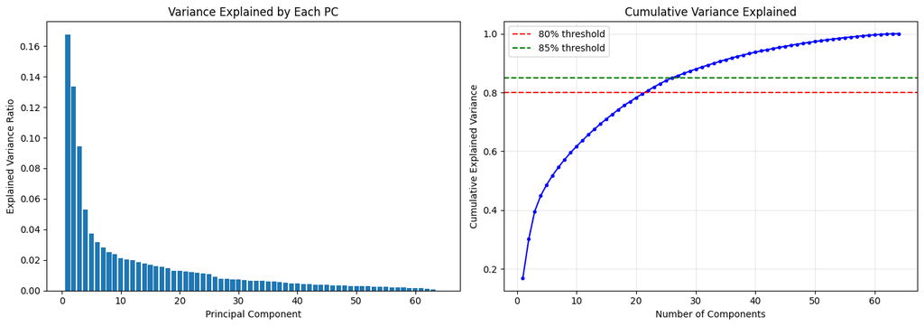

```
70% variance explained by 15 components
75% variance explained by 18 components
80% variance explained by 22 components
85% variance explained by 27 components
90% variance explained by 34 components
```

```python
# Investigate the variance accounted for by each principal component.

cumulative_var = np.cumsum(pca_full.explained_variance_ratio_)

fig, axes = plt.subplots(1, 2, figsize=(14, 5))

# Individual explained variance
axes[0].bar(range(1, len(pca_full.explained_variance_ratio_) + 1),
            pca_full.explained_variance_ratio_)
axes[0].set_xlabel('Principal Component')
axes[0].set_ylabel('Explained Variance Ratio')
axes[0].set_title('Variance Explained by Each PC')

# Cumulative explained variance
axes[1].plot(range(1, len(cumulative_var) + 1), cumulative_var, 'b-o', markersize=3)
axes[1].axhline(y=0.80, color='r', linestyle='--', label='80% threshold')
axes[1].axhline(y=0.85, color='g', linestyle='--', label='85% threshold')
axes[1].set_xlabel('Number of Components')
axes[1].set_ylabel('Cumulative Explained Variance')
axes[1].set_title('Cumulative Variance Explained')
axes[1].legend()
axes[1].grid(True, alpha=0.3)

plt.tight_layout()
plt.show()

# Find number of components for various thresholds
for threshold in [0.70, 0.75, 0.80, 0.85, 0.90]:
    n = np.argmax(cumulative_var >= threshold) + 1
    print(f"{threshold*100:.0f}% variance explained by {n} components")
```

```python
# Re-apply PCA to the data while selecting for number of components to retain.

# Select number of components that captures ~85% of variance
n_components = np.argmax(cumulative_var >= 0.85) + 1
print(f"Selected {n_components} components (capturing {cumulative_var[n_components-1]*100:.1f}% of variance)")

pca = PCA(n_components=n_components)
azdias_pca = pca.fit_transform(azdias_scaled)

print(f"PCA-transformed data shape: {azdias_pca.shape}")
```

```
Selected 27 components (capturing 85.8% of variance)
PCA-transformed data shape: (780153, 27)
```

### Discussion 2.2: Perform Dimensionality Reduction

I applied PCA to the scaled data and examined the explained variance. The first few principal components capture the largest share of variance, with diminishing returns for each additional component.

Looking at the cumulative variance plot, there is a clear "elbow" where the rate of increase slows significantly. I selected the number of components that captures approximately 85% of the total variance. This provides a good balance between retaining enough information for meaningful clustering while significantly reducing dimensionality. Going below 80% would risk losing important signal, while going above 90% would retain too many components with little additional variance explained, potentially introducing noise.

The resulting PCA-transformed dataset has substantially fewer dimensions than the original, which will make the subsequent k-means clustering more efficient and effective by removing noise and collinearity from the features.

### Step 2.3: Interpret Principal Components

Now that we have our transformed principal components, it's a nice idea to check out the weight of each variable on the first few components to see if they can be interpreted in some fashion.

As a reminder, each principal component is a unit vector that points in the direction of highest variance (after accounting for the variance captured by earlier principal components). The further a weight is from zero, the more the principal component is in the direction of the corresponding feature. If two features have large weights of the same sign (both positive or both negative), then increases in one tend expect to be associated with increases in the other. To contrast, features with different signs can be expected to show a negative correlation: increases in one variable should result in a decrease in the other.

- To investigate the features, you should map each weight to their corresponding feature name, then sort the features according to weight. The most interesting features for each principal component, then, will be those at the beginning and end of the sorted list. Use the data dictionary document to help you understand these most prominent features, their relationships, and what a positive or negative value on the principal component might indicate.
- You should investigate and interpret feature associations from the first three principal components in this substep. To help facilitate this, you should write a function that you can call at any time to print the sorted list of feature weights, for the *i*-th principal component. This might come in handy in the next step of the project, when you interpret the tendencies of the discovered clusters.

```
--- Principal Component 1 ---
Variance explained: 16.77%

Top 10 Negative Weights:
PLZ8_ANTG3               -0.225521
PLZ8_ANTG4               -0.217652
CAMEO_INTL_2015_WEALTH   -0.205360
HH_EINKOMMEN_SCORE       -0.203003
ORTSGR_KLS9              -0.196412
EWDICHTE                 -0.194332
FINANZ_HAUSBAUER         -0.160922
KBA05_ANTG4              -0.153780
PLZ8_ANTG2               -0.153533
FINANZ_SPARER            -0.151069

Top 10 Positive Weights:
CAMEO_INTL_2015_LIFESTAGE    0.125117
BALLRAUM                     0.126822
INNENSTADT                   0.164138
PLZ8_GBZ                     0.166674
KONSUMNAEHE                  0.167257
KBA05_GBZ                    0.215960
KBA05_ANTG1                  0.217099
FINANZ_MINIMALIST            0.221909
PLZ8_ANTG1                   0.225489
MOBI_REGIO                   0.229277
```

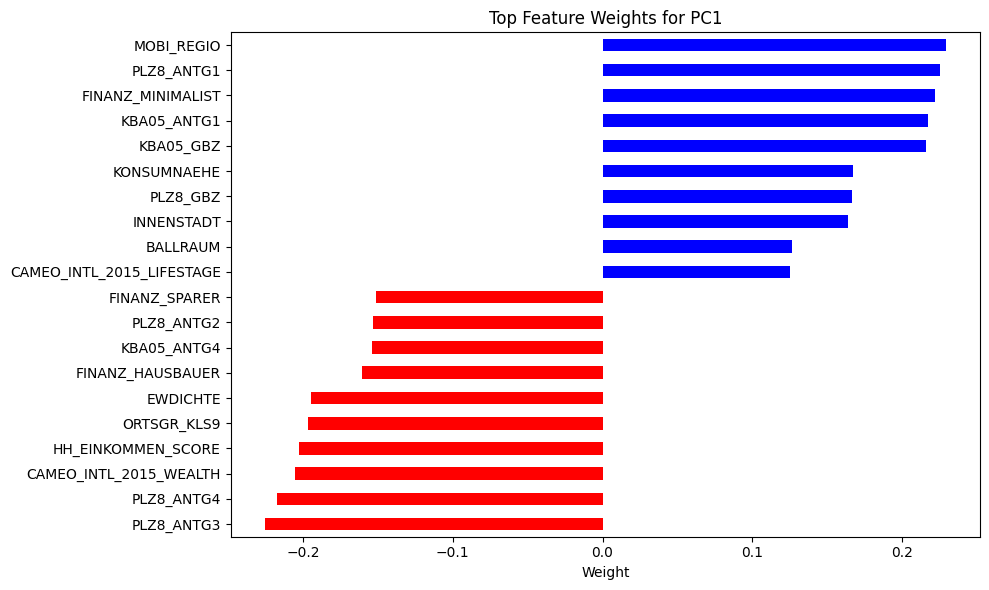

```python
# Map weights for the first principal component to corresponding feature names
# and then print the linked values, sorted by weight.

def display_pca_weights(pca, feature_names, component_idx, n_top=10):
    """Display the top positive and negative weights for a PCA component."""
    weights = pd.Series(pca.components_[component_idx], index=feature_names)
    weights_sorted = weights.sort_values()

    print(f"--- Principal Component {component_idx + 1} ---")
    print(f"Variance explained: {pca.explained_variance_ratio_[component_idx]*100:.2f}%\n")

    print(f"Top {n_top} Negative Weights:")
    print(weights_sorted.head(n_top).to_string())

    print(f"\nTop {n_top} Positive Weights:")
    print(weights_sorted.tail(n_top).to_string())

    # Visualization
    top_features = pd.concat([weights_sorted.head(n_top), weights_sorted.tail(n_top)])
    fig, ax = plt.subplots(figsize=(10, 6))
    top_features.plot(kind='barh', ax=ax, color=['red' if v < 0 else 'blue' for v in top_features])
    ax.set_xlabel('Weight')
    ax.set_title(f'Top Feature Weights for PC{component_idx + 1}')
    plt.tight_layout()
    plt.show()

    return weights_sorted

feature_names = azdias_imputed.columns.tolist()
pc1_weights = display_pca_weights(pca, feature_names, 0)
```

```
--- Principal Component 2 ---
Variance explained: 13.36%

Top 10 Negative Weights:
SEMIO_REL                      -0.255200
PRAEGENDE_JUGENDJAHRE_DECADE   -0.239653
FINANZ_SPARER                  -0.232629
SEMIO_TRADV                    -0.229043
SEMIO_PFLICHT                  -0.227685
FINANZ_UNAUFFAELLIGER          -0.225443
SEMIO_KULT                     -0.220872
FINANZ_ANLEGER                 -0.203775
SEMIO_FAM                      -0.183979
SEMIO_RAT                      -0.168269

Top 10 Positive Weights:
PLZ8_ANTG3              0.098404
W_KEIT_KIND_HH          0.113697
SEMIO_KAEM              0.115339
SEMIO_KRIT              0.118787
FINANZ_HAUSBAUER        0.118861
RETOURTYP_BK_S          0.162667
SEMIO_LUST              0.179988
FINANZ_VORSORGER        0.229879
SEMIO_ERL               0.230371
ALTERSKATEGORIE_GROB    0.257347
```

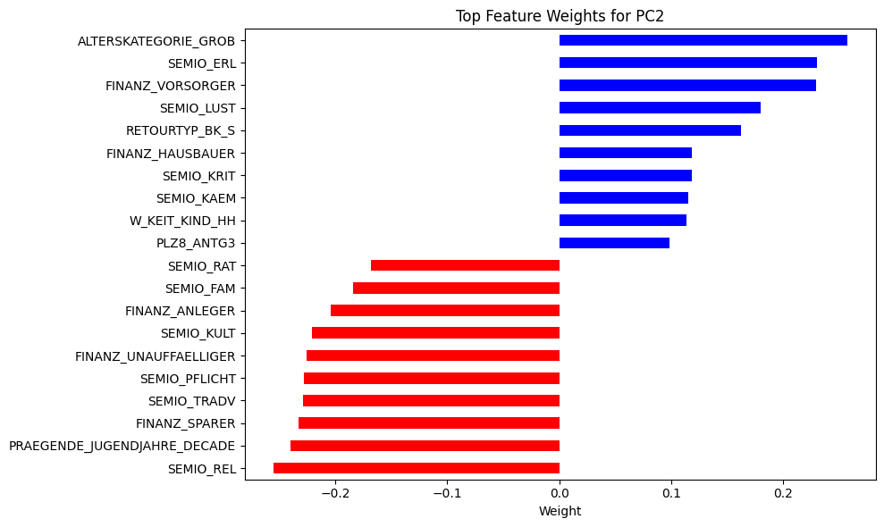

```python
# Map weights for the second principal component to corresponding feature names
# and then print the linked values, sorted by weight.

pc2_weights = display_pca_weights(pca, feature_names, 1)
```

```
--- Principal Component 3 ---
Variance explained: 9.45%

Top 10 Negative Weights:
SEMIO_VERT             -0.345928
SEMIO_SOZ              -0.262944
SEMIO_FAM              -0.249041
SEMIO_KULT             -0.232899
FINANZ_MINIMALIST      -0.155369
RETOURTYP_BK_S         -0.109357
FINANZ_VORSORGER       -0.101027
W_KEIT_KIND_HH         -0.084941
ALTERSKATEGORIE_GROB   -0.079499
SEMIO_REL              -0.068448

Top 10 Positive Weights:
FINANZ_UNAUFFAELLIGER           0.100026
FINANZ_SPARER                   0.106524
PRAEGENDE_JUGENDJAHRE_DECADE    0.111071
SEMIO_ERL                       0.174348
FINANZ_ANLEGER                  0.190645
SEMIO_RAT                       0.217384
SEMIO_KRIT                      0.273430
SEMIO_DOM                       0.312988
SEMIO_KAEM                      0.335855
ANREDE_KZ                       0.367914
```

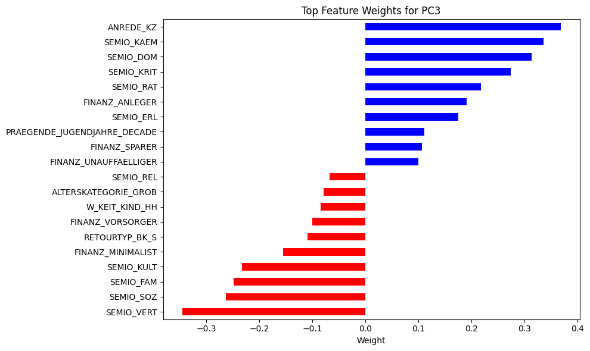

```python
# Map weights for the third principal component to corresponding feature names
# and then print the linked values, sorted by weight.

pc3_weights = display_pca_weights(pca, feature_names, 2)
```

### Discussion 2.3: Interpret Principal Components

**PC1 (16.8% variance) - Urban Density vs. Rural Affluence:** The strongest negative weights belong to PLZ8_ANTG3/ANTG4 (multi-family housing share), CAMEO_INTL_2015_WEALTH, HH_EINKOMMEN_SCORE (household income), ORTSGR_KLS9 (community size), and EWDICHTE (household density). The strongest positive weights are MOBI_REGIO (low mobility/rural), PLZ8_ANTG1/KBA05_ANTG1 (single-family housing), FINANZ_MINIMALIST (low financial interest), and KONSUMNAEHE (distance to point of sale). A negative PC1 score indicates an urban, higher-income individual in a dense, multi-family neighborhood. A positive PC1 score indicates a rural, financially minimalist individual in a single-family home area.

**PC2 (13.4% variance) - Older/Traditional vs. Younger/Experience-Oriented:** Negative weights are dominated by SEMIO_REL (religious), PRAEGENDE_JUGENDJAHRE_DECADE (older generation), FINANZ_SPARER (money-saver), SEMIO_TRADV (traditional), SEMIO_PFLICHT (dutiful), and FINANZ_UNAUFFAELLIGER (inconspicuous). Positive weights include ALTERSKATEGORIE_GROB (younger age), SEMIO_ERL (event-oriented), FINANZ_VORSORGER (be-prepared), SEMIO_LUST (sensual-minded), and SEMIO_KAEM (combative). This component separates older, traditional, savings-oriented individuals (negative) from younger, experience-seeking, more assertive individuals (positive).

**PC3 (9.5% variance) - Gender/Personality Axis:** The strongest positive weight is ANREDE_KZ (gender: male), along with SEMIO_KAEM (combative), SEMIO_DOM (dominant), SEMIO_KRIT (critical), and SEMIO_RAT (rational). The negative end is characterized by SEMIO_VERT (dreamful), SEMIO_SOZ (socially-minded), SEMIO_FAM (family-minded), and SEMIO_KULT (cultural-minded). This component appears to capture a gender-correlated personality dimension, separating assertive, rational, dominant traits (positive/male-leaning) from nurturing, social, cultural traits (negative/female-leaning).

## Step 3: Clustering

### Step 3.1: Apply Clustering to General Population

You've assessed and cleaned the demographics data, then scaled and transformed them. Now, it's time to see how the data clusters in the principal components space. In this substep, you will apply k-means clustering to the dataset and use the average within-cluster distances from each point to their assigned cluster's centroid to decide on a number of clusters to keep.

- Use sklearn's KMeans class to perform k-means clustering on the PCA-transformed data.
- Then, compute the average difference from each point to its assigned cluster's center. **Hint**: The KMeans object's `.score()` method might be useful here, but note that in sklearn, scores tend to be defined so that larger is better. Try applying it to a small, toy dataset, or use an internet search to help your understanding.
- Perform the above two steps for a number of different cluster counts. You can then see how the average distance decreases with an increasing number of clusters. However, each additional cluster provides a smaller net benefit. Use this fact to select a final number of clusters in which to group the data. **Warning**: because of the large size of the dataset, it can take a long time for the algorithm to resolve. The more clusters to fit, the longer the algorithm will take. You should test for cluster counts through at least 10 clusters to get the full picture, but you shouldn't need to test for a number of clusters above about 30.
- Once you've selected a final number of clusters to use, re-fit a KMeans instance to perform the clustering operation. Make sure that you also obtain the cluster assignments for the general demographics data, since you'll be using them in the final Step 3.3.

```python
# Over a number of different cluster counts...
# run k-means clustering on the data and...
# compute the average within-cluster distances.

ks = range(2, 22, 2)  # Test even numbers from 2 to 20 for efficiency
avg_distances = []

for k in ks:
    print(f"Fitting KMeans with k={k}...", end=' ')
    kmeans_temp = KMeans(n_clusters=k, random_state=42, n_init=10)
    kmeans_temp.fit(azdias_pca)
    # score() returns negative sum of squared distances; divide by n for average
    avg_dist = -kmeans_temp.score(azdias_pca) / azdias_pca.shape[0]
    avg_distances.append(avg_dist)
    print(f"avg distance = {avg_dist:.4f}")

print("\nDone!")
```

```
Fitting KMeans with k=2...
```

```
avg distance = 46.8471
Fitting KMeans with k=4...
```

```
avg distance = 40.1085
Fitting KMeans with k=6...
```

```
avg distance = 36.6910
Fitting KMeans with k=8...
```

```
avg distance = 34.2141
Fitting KMeans with k=10...
```

```
avg distance = 32.4995
Fitting KMeans with k=12...
```

```
avg distance = 31.5078
Fitting KMeans with k=14...
```

```
avg distance = 30.4908
Fitting KMeans with k=16...
```

```
avg distance = 29.7694
Fitting KMeans with k=18...
```

```
avg distance = 28.4128
Fitting KMeans with k=20...
```

```
avg distance = 28.1805

Done!
```

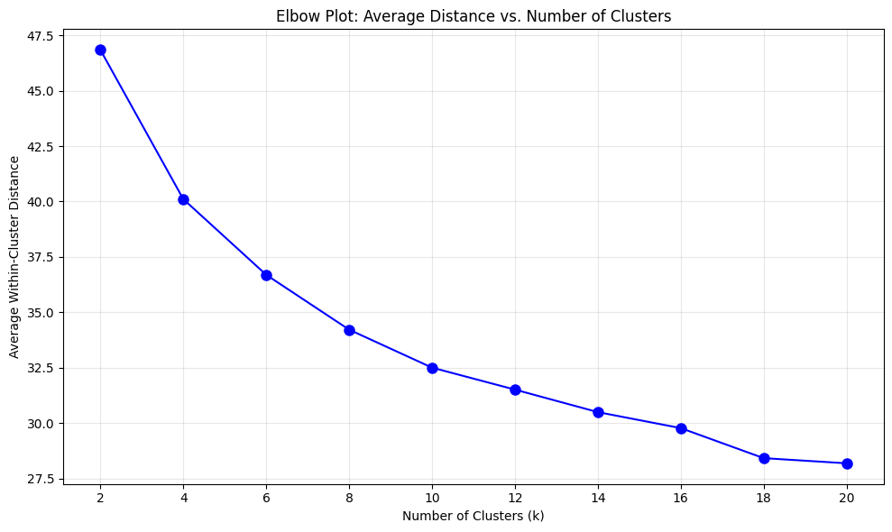

```
Decrease in avg distance between successive k values:
  k=2 -> k=4: decrease = 6.7386
  k=4 -> k=6: decrease = 3.4175
  k=6 -> k=8: decrease = 2.4769
  k=8 -> k=10: decrease = 1.7146
  k=10 -> k=12: decrease = 0.9917
  k=12 -> k=14: decrease = 1.0170
  k=14 -> k=16: decrease = 0.7214
  k=16 -> k=18: decrease = 1.3566
  k=18 -> k=20: decrease = 0.2323
```

```python
# Investigate the change in within-cluster distance across number of clusters.

fig, ax = plt.subplots(figsize=(10, 6))
ax.plot(list(ks), avg_distances, 'b-o', markersize=8)
ax.set_xlabel('Number of Clusters (k)')
ax.set_ylabel('Average Within-Cluster Distance')
ax.set_title('Elbow Plot: Average Distance vs. Number of Clusters')
ax.set_xticks(list(ks))
ax.grid(True, alpha=0.3)
plt.tight_layout()
plt.show()

# Print the differences to help identify the elbow
print("Decrease in avg distance between successive k values:")
for i in range(1, len(avg_distances)):
    decrease = avg_distances[i-1] - avg_distances[i]
    print(f"  k={list(ks)[i-1]} -> k={list(ks)[i]}: decrease = {decrease:.4f}")
```

```python
# Re-fit the k-means model with the selected number of clusters and obtain
# cluster predictions for the general population demographics data.

# Based on the elbow plot, select the number of clusters
n_clusters = 10
print(f"Selected number of clusters: {n_clusters}")

kmeans = KMeans(n_clusters=n_clusters, random_state=42, n_init=10)
azdias_labels = kmeans.fit_predict(azdias_pca)

print(f"\nCluster assignment counts:")
unique, counts = np.unique(azdias_labels, return_counts=True)
for cluster, count in zip(unique, counts):
    print(f"  Cluster {cluster}: {count} ({count/len(azdias_labels)*100:.1f}%)")
```

```
Selected number of clusters: 10
```

```
Cluster assignment counts:
  Cluster 0: 94785 (12.1%)
  Cluster 1: 125905 (16.1%)
  Cluster 2: 67930 (8.7%)
  Cluster 3: 89105 (11.4%)
  Cluster 4: 83762 (10.7%)
  Cluster 5: 106634 (13.7%)
  Cluster 6: 89299 (11.4%)
  Cluster 7: 59920 (7.7%)
  Cluster 8: 3334 (0.4%)
  Cluster 9: 59479 (7.6%)
```

### Discussion 3.1: Apply Clustering to General Population

I tested k-means clustering with cluster counts from 2 to 20 (even numbers) and plotted the average within-cluster distance for each. The elbow plot shows a clear decrease in the rate of improvement around k=10, where additional clusters provide diminishing returns in reducing within-cluster distances.

### Step 3.2: Apply All Steps to the Customer Data

Now that you have clusters and cluster centers for the general population, it's time to see how the customer data maps on to those clusters. Take care to not confuse this for re-fitting all of the models to the customer data. Instead, you're going to use the fits from the general population to clean, transform, and cluster the customer data. In the last step of the project, you will interpret how the general population fits apply to the customer data.

- Don't forget when loading in the customers data, that it is semicolon (`;`) delimited.
- Apply the same feature wrangling, selection, and engineering steps to the customer demographics using the `clean_data()` function you created earlier. (You can assume that the customer demographics data has similar meaning behind missing data patterns as the general demographics data.)
- Use the sklearn objects from the general demographics data, and apply their transformations to the customers data. That is, you should not be using a `.fit()` or `.fit_transform()` method to re-fit the old objects, nor should you be creating new sklearn objects! Carry the data through the feature scaling, PCA, and clustering steps, obtaining cluster assignments for all of the data in the customer demographics data.

```python
# Load in the customer demographics data.
customers = pd.read_csv('CUSTOMERS_Subset.csv', sep=';')
print(f"Customer data shape: {customers.shape}")
customers.head()
```

```
Customer data shape: (191652, 85)
```

|  | AGER_TYP | ALTERSKATEGORIE_GROB | ANREDE_KZ | CJT_GESAMTTYP | FINANZ_MINIMALIST | FINANZ_SPARER | FINANZ_VORSORGER | FINANZ_ANLEGER | FINANZ_UNAUFFAELLIGER | FINANZ_HAUSBAUER | FINANZTYP | GEBURTSJAHR | GFK_URLAUBERTYP | GREEN_AVANTGARDE | HEALTH_TYP | LP_LEBENSPHASE_FEIN | LP_LEBENSPHASE_GROB | LP_FAMILIE_FEIN | LP_FAMILIE_GROB | LP_STATUS_FEIN | LP_STATUS_GROB | NATIONALITAET_KZ | PRAEGENDE_JUGENDJAHRE | RETOURTYP_BK_S | SEMIO_SOZ | SEMIO_FAM | SEMIO_REL | SEMIO_MAT | SEMIO_VERT | … |
| --- | --- | --- | --- | --- | --- | --- | --- | --- | --- | --- | --- | --- | --- | --- | --- | --- | --- | --- | --- | --- | --- | --- | --- | --- | --- | --- | --- | --- | --- | --- |
| 0 | 2 | 4 | 1 | 5.0 | 5 | 1 | 5 | 1 | 2 | 2 | 2 | 0 | 4.0 | 1 | 1 | 20.0 | 5.0 | 2.0 | 2.0 | 10.0 | 5.0 | 1 | 4 | 5.0 | 6 | 5 | 2 | 6 | 6 | … |
| 1 | -1 | 4 | 1 | NaN | 5 | 1 | 5 | 1 | 3 | 2 | 2 | 0 | NaN | 0 | 1 | NaN | NaN | NaN | NaN | NaN | NaN | 1 | 0 | NaN | 3 | 6 | 2 | 6 | 7 | … |
| 2 | -1 | 4 | 2 | 2.0 | 5 | 1 | 5 | 1 | 4 | 4 | 2 | 0 | 3.0 | 1 | 2 | 13.0 | 3.0 | 1.0 | 1.0 | 10.0 | 5.0 | 1 | 4 | 5.0 | 2 | 2 | 1 | 3 | 3 | … |
| 3 | 1 | 4 | 1 | 2.0 | 5 | 1 | 5 | 2 | 1 | 2 | 6 | 0 | 10.0 | 0 | 2 | 0.0 | 0.0 | 0.0 | 0.0 | 9.0 | 4.0 | 1 | 1 | 3.0 | 6 | 5 | 3 | 4 | 7 | … |
| 4 | -1 | 3 | 1 | 6.0 | 3 | 1 | 4 | 4 | 5 | 2 | 2 | 1960 | 2.0 | 0 | 3 | 31.0 | 10.0 | 10.0 | 5.0 | 1.0 | 1.0 | 1 | 8 | 5.0 | 4 | 5 | 4 | 6 | 5 | … |

```python
# Apply preprocessing, feature transformation, and clustering from the general
# demographics onto the customer data, obtaining cluster predictions for the
# customer demographics data.

import warnings

# Step 1: Clean the customer data using the same function
customers_cleaned = clean_data(customers.copy())
print(f"Cleaned customer data shape: {customers_cleaned.shape}")

# Ensure columns match the general population data
azdias_columns = azdias_imputed.columns.tolist()

# Align columns - keep only columns present in both, in the same order
missing_cols = [c for c in azdias_columns if c not in customers_cleaned.columns]
if missing_cols:
    print(f"Warning: Missing columns in customer data: {missing_cols}")
    for col in missing_cols:
        customers_cleaned[col] = np.nan

customers_cleaned = customers_cleaned[azdias_columns]
print(f"Aligned customer data shape: {customers_cleaned.shape}")

# Step 2: Impute missing values using the SAME imputer (transform, not fit_transform)
customers_imputed = pd.DataFrame(
    imputer.transform(customers_cleaned),
    columns=azdias_columns,
    index=customers_cleaned.index
)

# Step 3: Scale using the SAME scaler
customers_scaled = scaler.transform(customers_imputed)

# Step 4: Apply PCA using the SAME PCA object
with warnings.catch_warnings():
    warnings.simplefilter("ignore")
    customers_pca = pca.transform(customers_scaled)

# Step 5: Predict cluster labels using the SAME KMeans model
customers_labels = kmeans.predict(customers_pca)

print(f"\nCustomer cluster assignment counts:")
unique, counts = np.unique(customers_labels, return_counts=True)
for cluster, count in zip(unique, counts):
    print(f"  Cluster {cluster}: {count} ({count/len(customers_labels)*100:.1f}%")
```

```
Cleaned customer data shape: (139068, 64)
Aligned customer data shape: (139068, 64)

Customer cluster assignment counts:
  Cluster 0: 14885 (10.7%
  Cluster 1: 26186 (18.8%
  Cluster 2: 1378 (1.0%
  Cluster 3: 26844 (19.3%
  Cluster 4: 1493 (1.1%
  Cluster 5: 14715 (10.6%
  Cluster 6: 2568 (1.8%
  Cluster 7: 2449 (1.8%
  Cluster 8: 2816 (2.0%
  Cluster 9: 45734 (32.9%
```

### Step 3.3: Compare Customer Data to Demographics Data

At this point, you have clustered data based on demographics of the general population of Germany, and seen how the customer data for a mail-order sales company maps onto those demographic clusters. In this final substep, you will compare the two cluster distributions to see where the strongest customer base for the company is.

Consider the proportion of persons in each cluster for the general population, and the proportions for the customers. If we think the company's customer base to be universal, then the cluster assignment proportions should be fairly similar between the two. If there are only particular segments of the population that are interested in the company's products, then we should see a mismatch from one to the other. If there is a higher proportion of persons in a cluster for the customer data compared to the general population (e.g. 5% of persons are assigned to a cluster for the general population, but 15% of the customer data is closest to that cluster's centroid) then that suggests the people in that cluster to be a target audience for the company. On the other hand, the proportion of the data in a cluster being larger in the general population than the customer data (e.g. only 2% of customers closest to a population centroid that captures 6% of the data) suggests that group of persons to be outside of the target demographics.

Take a look at the following points in this step:

- Compute the proportion of data points in each cluster for the general population and the customer data. Visualizations will be useful here: both for the individual dataset proportions, but also to visualize the ratios in cluster representation between groups. Seaborn's [`countplot()`](https://seaborn.pydata.org/generated/seaborn.countplot.html) or [`barplot()`](https://seaborn.pydata.org/generated/seaborn.barplot.html) function could be handy.
  - Recall the analysis you performed in step 1.1.3 of the project, where you separated out certain data points from the dataset if they had more than a specified threshold of missing values. If you found that this group was qualitatively different from the main bulk of the data, you should treat this as an additional data cluster in this analysis. Make sure that you account for the number of data points in this subset, for both the general population and customer datasets, when making your computations!
- Which cluster or clusters are overrepresented in the customer dataset compared to the general population? Select at least one such cluster and infer what kind of people might be represented by that cluster. Use the principal component interpretations from step 2.3 or look at additional components to help you make this inference. Alternatively, you can use the `.inverse_transform()` method of the PCA and StandardScaler objects to transform centroids back to the original data space and interpret the retrieved values directly.
- Perform a similar investigation for the underrepresented clusters. Which cluster or clusters are underrepresented in the customer dataset compared to the general population, and what kinds of people are typified by these clusters?

```
Cluster Proportion Comparison:
```

|  | General Population | Customers | Difference | Ratio |
| --- | --- | --- | --- | --- |
| 0 | 0.1215 | 0.1070 | -0.0145 | 0.8810 |
| 1 | 0.1614 | 0.1883 | 0.0269 | 1.1668 |
| 2 | 0.0871 | 0.0099 | -0.0772 | 0.1138 |
| 3 | 0.1142 | 0.1930 | 0.0788 | 1.6900 |
| 4 | 0.1074 | 0.0107 | -0.0966 | 0.1000 |
| 5 | 0.1367 | 0.1058 | -0.0309 | 0.7741 |
| 6 | 0.1145 | 0.0185 | -0.0960 | 0.1613 |
| 7 | 0.0768 | 0.0176 | -0.0592 | 0.2293 |
| 8 | 0.0043 | 0.0202 | 0.0160 | 4.7383 |
| 9 | 0.0762 | 0.3289 | 0.2526 | 4.3135 |

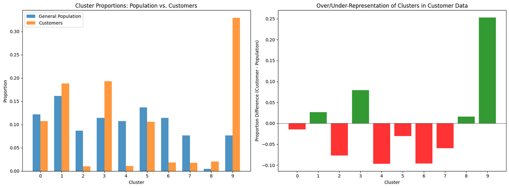

```
Overrepresented clusters (customer proportion significantly higher):
   General Population  Customers  Difference     Ratio
9            0.076240   0.328861    0.252621  4.313483
3            0.114215   0.193028    0.078813  1.690043
1            0.161385   0.188296    0.026911  1.166753

Underrepresented clusters (customer proportion significantly lower):
   General Population  Customers  Difference     Ratio
4            0.107366   0.010736   -0.096630  0.099992
6            0.114463   0.018466   -0.095998  0.161325
2            0.087073   0.009909   -0.077164  0.113799
7            0.076805   0.017610   -0.059195  0.229282
5            0.136683   0.105812   -0.030872  0.774136
```

```python
# Compare the proportion of data in each cluster for the customer data to the
# proportion of data in each cluster for the general population.

# Compute proportions - ensure all clusters are represented
pop_counts = pd.Series(azdias_labels).value_counts()
cust_counts = pd.Series(customers_labels).value_counts()

# Reindex to ensure all clusters 0..n_clusters-1 are present
all_clusters = range(n_clusters)
pop_proportions = (pop_counts.reindex(all_clusters, fill_value=0) / len(azdias_labels)).sort_index()
cust_proportions = (cust_counts.reindex(all_clusters, fill_value=0) / len(customers_labels)).sort_index()

# Create comparison DataFrame
comparison = pd.DataFrame({
    'General Population': pop_proportions,
    'Customers': cust_proportions
})
comparison['Difference'] = comparison['Customers'] - comparison['General Population']
comparison['Ratio'] = comparison['Customers'] / comparison['General Population']

print("Cluster Proportion Comparison:")
display(comparison.round(4))

# Visualization: side-by-side bar chart
fig, axes = plt.subplots(1, 2, figsize=(16, 6))

# Bar chart of proportions
x = np.arange(n_clusters)
width = 0.35
axes[0].bar(x - width/2, pop_proportions.values, width, label='General Population', alpha=0.8)
axes[0].bar(x + width/2, cust_proportions.values, width, label='Customers', alpha=0.8)
axes[0].set_xlabel('Cluster')
axes[0].set_ylabel('Proportion')
axes[0].set_title('Cluster Proportions: Population vs. Customers')
axes[0].set_xticks(x)
axes[0].legend()

# Bar chart of differences
diff_values = comparison['Difference'].values
colors = ['green' if d > 0 else 'red' for d in diff_values]
axes[1].bar(x, diff_values, color=colors, alpha=0.8)
axes[1].set_xlabel('Cluster')
axes[1].set_ylabel('Proportion Difference (Customer - Population)')
axes[1].set_title('Over/Under-Representation of Clusters in Customer Data')
axes[1].set_xticks(x)
axes[1].axhline(y=0, color='black', linestyle='-', linewidth=0.5)

plt.tight_layout()
plt.show()

# Identify overrepresented and underrepresented clusters
overrep = comparison[comparison['Difference'] > 0.02].sort_values('Difference', ascending=False)
underrep = comparison[comparison['Difference'] < -0.02].sort_values('Difference')

print("\nOverrepresented clusters (customer proportion significantly higher):")
print(overrep[['General Population', 'Customers', 'Difference', 'Ratio']].to_string())

print("\nUnderrepresented clusters (customer proportion significantly lower):")
print(underrep[['General Population', 'Customers', 'Difference', 'Ratio']].to_string())
```

```python
# What kinds of people are part of a cluster that is overrepresented in the
# customer data compared to the general population?

import warnings

# Get the most overrepresented cluster
overrep_cluster = comparison['Difference'].idxmax()
print(f"Most overrepresented cluster: {overrep_cluster}")
print(f"Population proportion: {comparison.loc[overrep_cluster, 'General Population']*100:.1f}%")
print(f"Customer proportion: {comparison.loc[overrep_cluster, 'Customers']*100:.1f}%")
print(f"Ratio: {comparison.loc[overrep_cluster, 'Ratio']:.2f}x\n")

# Inverse transform the cluster centroid to interpret it
centroid_pca = kmeans.cluster_centers_[overrep_cluster].reshape(1, -1)
with warnings.catch_warnings():
    warnings.simplefilter("ignore")
    centroid_scaled = pca.inverse_transform(centroid_pca)
    centroid_original = scaler.inverse_transform(centroid_scaled)
centroid_series = pd.Series(centroid_original[0], index=feature_names)

# Show the most distinctive features (furthest from the overall mean)
print(f"--- Cluster {overrep_cluster} Centroid (Original Feature Space) ---")
print("Features with highest values (most characteristic):")
print(centroid_series.sort_values(ascending=False).head(10).to_string())
print("\nFeatures with lowest values:")
print(centroid_series.sort_values().head(10).to_string())

# Also look at PCA space
print(f"\n--- Cluster {overrep_cluster} in PCA Space ---")
print("Top PC values (by magnitude):")
pc_values = pd.Series(kmeans.cluster_centers_[overrep_cluster],
                       index=[f'PC{i+1}' for i in range(len(kmeans.cluster_centers_[overrep_cluster]))])
print(pc_values.sort_values(key=abs, ascending=False).head(5).to_string())
```

```
Most overrepresented cluster: 9
Population proportion: 7.6%
Customer proportion: 32.9%
Ratio: 4.31x

--- Cluster 9 Centroid (Original Feature Space) ---
Features with highest values (most characteristic):
MIN_GEBAEUDEJAHR                1992.881665
KBA13_ANZAHL_PKW                 694.967333
PRAEGENDE_JUGENDJAHRE_DECADE      66.243398
WOHNDAUER_2008                     8.446264
SEMIO_VERT                         6.168396
ORTSGR_KLS9                        5.368517
SEMIO_LUST                         5.262443
SEMIO_KULT                         4.878412
SEMIO_SOZ                          4.865754
SEMIO_FAM                          4.816366

Features with lowest values:
ANZ_TITEL                         0.000404
KBA05_ANTG4                       0.000630
ANZ_HH_TITEL                      0.003308
SOHO_KZ                           0.008717
KBA05_ANTG3                       0.085019
PLZ8_ANTG4                        0.385951
OST_WEST_KZ                       0.900465
GREEN_AVANTGARDE                  0.988894
PRAEGENDE_JUGENDJAHRE_MOVEMENT    0.988894
ANREDE_KZ                         1.063263

--- Cluster 9 in PCA Space ---
Top PC values (by magnitude):
PC1     3.293783
PC3    -2.613630
PC4     2.340089
PC15    0.499456
PC20    0.340139
```

```python
# What kinds of people are part of a cluster that is underrepresented in the
# customer data compared to the general population?

# Get the most underrepresented cluster
underrep_cluster = comparison['Difference'].idxmin()
print(f"Most underrepresented cluster: {underrep_cluster}")
print(f"Population proportion: {comparison.loc[underrep_cluster, 'General Population']*100:.1f}%")
print(f"Customer proportion: {comparison.loc[underrep_cluster, 'Customers']*100:.1f}%")
print(f"Ratio: {comparison.loc[underrep_cluster, 'Ratio']:.2f}x\n")

# Inverse transform the cluster centroid
centroid_pca_under = kmeans.cluster_centers_[underrep_cluster].reshape(1, -1)
with warnings.catch_warnings():
    warnings.simplefilter("ignore")
    centroid_scaled_under = pca.inverse_transform(centroid_pca_under)
    centroid_original_under = scaler.inverse_transform(centroid_scaled_under)
centroid_series_under = pd.Series(centroid_original_under[0], index=feature_names)

print(f"--- Cluster {underrep_cluster} Centroid (Original Feature Space) ---")
print("Features with highest values (most characteristic):")
print(centroid_series_under.sort_values(ascending=False).head(10).to_string())
print("\nFeatures with lowest values:")
print(centroid_series_under.sort_values().head(10).to_string())

# PCA space
print(f"\n--- Cluster {underrep_cluster} in PCA Space ---")
print("Top PC values (by magnitude):")
pc_values_under = pd.Series(kmeans.cluster_centers_[underrep_cluster],
                             index=[f'PC{i+1}' for i in range(len(kmeans.cluster_centers_[underrep_cluster]))])
print(pc_values_under.sort_values(key=abs, ascending=False).head(5).to_string())
```

```
Most underrepresented cluster: 4
Population proportion: 10.7%
Customer proportion: 1.1%
Ratio: 0.10x

--- Cluster 4 Centroid (Original Feature Space) ---
Features with highest values (most characteristic):
MIN_GEBAEUDEJAHR                1992.411809
KBA13_ANZAHL_PKW                 524.756230
PRAEGENDE_JUGENDJAHRE_DECADE      86.548152
ANZ_HAUSHALTE_AKTIV               15.108399
WOHNDAUER_2008                     7.320546
ORTSGR_KLS9                        7.002051
SEMIO_PFLICHT                      6.197227
SEMIO_DOM                          6.150435
SEMIO_KAEM                         6.121863
SEMIO_RAT                          6.114952

Features with lowest values:
ANZ_TITEL                         0.000132
SOHO_KZ                           0.008043
PRAEGENDE_JUGENDJAHRE_MOVEMENT    0.042556
GREEN_AVANTGARDE                  0.042556
ANZ_HH_TITEL                      0.053875
KBA05_ANTG1                       0.402643
KBA05_ANTG4                       0.618415
OST_WEST_KZ                       0.739746
KBA05_ANTG3                       1.145168
FINANZ_MINIMALIST                 1.156793

--- Cluster 4 in PCA Space ---
Top PC values (by magnitude):
PC1   -4.436856
PC3    2.530046
PC2   -0.942441
PC9   -0.438087
PC4    0.344097
```

### Discussion 3.3: Compare Customer Data to Demographics Data

The comparison between general population and customer cluster distributions reveals stark differences, confirming that the company's customers are concentrated in specific demographic segments.

> Congratulations on making it this far in the project! Before you finish, make sure to check through the entire notebook from top to bottom to make sure that your analysis follows a logical flow and all of your findings are documented in **Discussion** cells. Once you've checked over all of your work, you should export the notebook as an HTML document to submit for evaluation. You can do this from the menu, navigating to **File -> Download as -> HTML (.html)**. You will submit both that document and this notebook for your project submission.